# LOH_H2O2_20160223_summary

h qin

Feb 23, 2016

20160121, start to port old R codes into a markdown file.

2013 Dec 9, using results from _3b.2013Dec9.summarizeFitting.H2O2LOH.R

2013Nov25, use summarized results from _3.*R, which contains standard deviations.

2008 CLS data uses M14, 2013H2O2 uses SGU57, so only 10 strains overlaps

Use 2013 fitting results and gnls reults: 2013Nov14, use correlated regression; Reverse L0 axis in plot, 2012 July 30

2012Feb25, Tg.vs.Tc ~ ln(R0) + G

Partial correlations are all negative, what does this mean? Of couse, they should be negative correlations.

Tg/Tc is a measure of ability to maintian recombiation rate during aging

```r
rm( list = ls() );
setwd("~/github/LOH_H2O2_2016/analysis")
```

Load 2013 H2O2-LOH results

```r
 list.files(pattern="csv", path='output')
```

```
## [1] "LOHH2O2_all_20131127.csv"        "LOHH2O2_averaged20131210_v1.csv"
```

```r
 tb2 = read.csv("output/LOHH2O2_averaged20131210_v1.csv")
```

Load previous LOH-CLS results, Qin Plos One 2008

```r
#tb = read.table("summary.new.by.strain.csv", header=T, sep="\t");
 tb = read.table("021307.summary.by.strain.csv", header=T, sep="\t");
 tb.old = tb;
 labels = names( tb.old );
 tb = tb.old[, c("strain","ARLS","R0","G","CLS","Tc", "Tg","Tmmax","Tbmax", "Td", "Tdmax","TLmax","Lmax",
 "b.max", "b.min", "strains", "L0.all", "L0.small" , "Pbt0","Pb0.5t0", "Pbt0.b") ];
 tb$CLS.vs.Tc = tb$CLS / tb$Tc;
 tb$Tg.vs.Tc = tb$Tg / tb$Tc;
 tb$strain = as.character(tb$strain)
 tb.old = tb;
 tb = tb.old[1:13,] #remove rad52DD
 tb.test = tb[1:11,]
```

```r
 summary(lm(Tg.vs.Tc ~ ARLS, data=tb.test)) #re-run the old results, just to double-check
```

```
##
## Call:
## lm(formula = Tg.vs.Tc ~ ARLS, data = tb.test)
##
## Residuals:
##      Min       1Q   Median       3Q      Max
## -0.28096 -0.10360  0.03093  0.13209  0.23406
##
## Coefficients:
##             Estimate Std. Error t value Pr(>|t|)
## (Intercept) -0.03702    0.41283  -0.090  0.93052
## ARLS         0.04439    0.01310   3.388  0.00803 **
## ---
## Signif. codes:  0 '***' 0.001 '**' 0.01 '*' 0.05 '.' 0.1 ' ' 1
##
## Residual standard error: 0.1857 on 9 degrees of freedom
## Multiple R-squared:  0.5605, Adjusted R-squared:  0.5117
## F-statistic: 11.48 on 1 and 9 DF,  p-value: 0.008026
```

```r
 summary(lm( 1/Tg.vs.Tc ~ ARLS, data=tb.test)) #good, negative, p=0.012
```

```
##
## Call:
## lm(formula = 1/Tg.vs.Tc ~ ARLS, data = tb.test)
##
## Residuals:
##      Min       1Q   Median       3Q      Max
## -0.15828 -0.06543 -0.01532  0.04604  0.22840
##
## Coefficients:
##             Estimate Std. Error t value Pr(>|t|)
## (Intercept)  1.54881    0.25270   6.129 0.000173 ***
## ARLS        -0.02499    0.00802  -3.115 0.012408 *
## ---
## Signif. codes:  0 '***' 0.001 '**' 0.01 '*' 0.05 '.' 0.1 ' ' 1
##
## Residual standard error: 0.1137 on 9 degrees of freedom
## Multiple R-squared:  0.5189, Adjusted R-squared:  0.4654
## F-statistic: 9.706 on 1 and 9 DF,  p-value: 0.01241
```

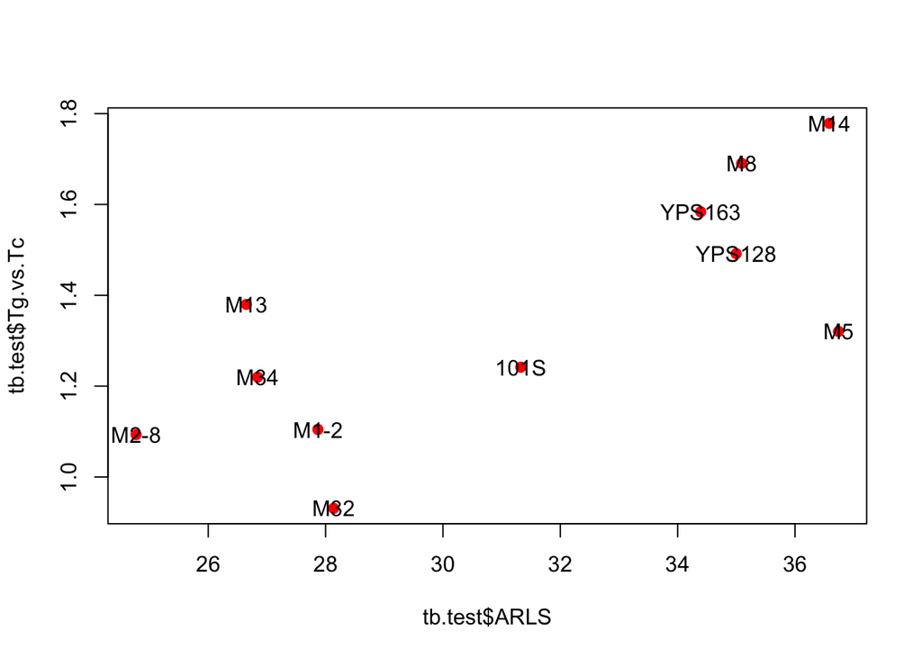

```r
 plot( tb.test$Tg.vs.Tc ~ tb.test$ARLS, col='red', pch=19 )
 text(tb.test$ARLS, tb.test$Tg.vs.Tc, tb.test$strains)
```

Load exg06 data

```r
 nat = read.table("062705.rls.cls.tab", sep="\t", header=T, colClasses=c("character", rep(NA,4)) );
```

Merge tb and tb2. The merged table is ‘tb3’

```r
 tb2$strain = tb2$strains
 #tb3a = merge(tb, tb2, by='strain', all=T)
 tb3 = merge(tb, tb2, by='strain')
 tb3 = tb3[ , -(grep('strains', names(tb3))) ]

 #remove BY4743 will left only natural isolates, but some pvalue will exceed 0.05 cutoff.
 #So, have to leave BY4743 in the data set, and do not claim natural variaitons.
 # tb3 = tb3[ tb3$strain != "BY4743", ]
```

Plot of Cb.vs.Cv ~ ARLS. The key conclusion.

```r
 #summary(lm(tb3$Cv.vs.Cb ~ tb3$ARLS)) #p 0.078
 summary(lm(tb3$Cb.vs.Cv ~ tb3$ARLS)) #p 0.039
```

```
##
## Call:
## lm(formula = tb3$Cb.vs.Cv ~ tb3$ARLS)
##
## Residuals:
##     Min      1Q  Median      3Q     Max
## -0.8629 -0.2748 -0.1479  0.3616  0.8908
##
## Coefficients:
##             Estimate Std. Error t value Pr(>|t|)
## (Intercept) -1.60720    1.07869  -1.490   0.1671
## tb3$ARLS     0.08356    0.03524   2.371   0.0392 *
## ---
## Signif. codes:  0 '***' 0.001 '**' 0.01 '*' 0.05 '.' 0.1 ' ' 1
##
## Residual standard error: 0.528 on 10 degrees of freedom
## Multiple R-squared:  0.3599, Adjusted R-squared:  0.2958
## F-statistic: 5.622 on 1 and 10 DF,  p-value: 0.03921
```

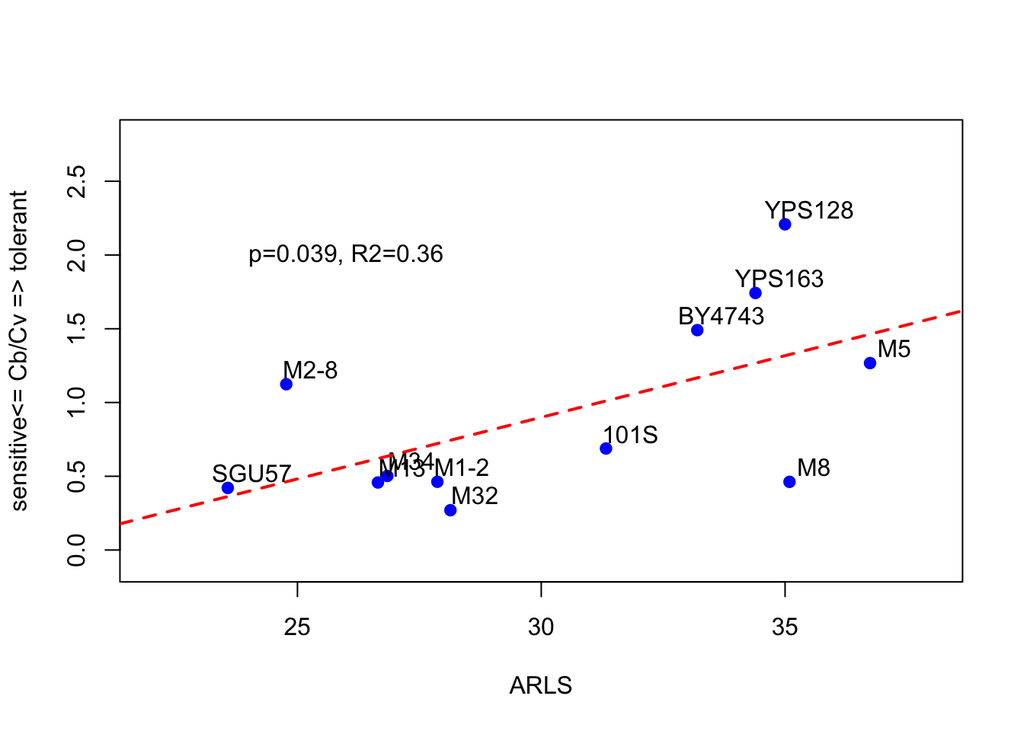

```r
 plot( tb3$Cb.vs.Cv ~ tb3$ARLS, col='blue', pch=19, xlab='ARLS', ylab='sensitive<= Cb/Cv => tolerant', xlim=c(22,38),ylim=c(-0.1,2.8) )
 text(tb3$ARLS + 0.5, tb3$Cb.vs.Cv+0.1, tb3$strain)
 m = lm(tb3$Cb.vs.Cv ~ tb3$ARLS )
 abline(m, col='red', lty=2, lwd=2)
 text(26, 2.0, "p=0.039, R2=0.36")
```

Cb.vs.Cv ~ L0.all and L0.small. L0.small is no good, probably because L0.small has high level of noises?

```r
 #summary(lm(1/ tb3$Cb.vs.Cv ~ tb3$L0.small)) # p =0.685
 summary(lm( tb3$Cb.vs.Cv ~  tb3$L0.all)) # p=0.0079
```

```
##
## Call:
## lm(formula = tb3$Cb.vs.Cv ~ tb3$L0.all)
##
## Residuals:
##      Min       1Q   Median       3Q      Max
## -0.67801 -0.24589  0.08283  0.16792  0.92957
##
## Coefficients:
##             Estimate Std. Error t value Pr(>|t|)
## (Intercept)  -0.2050     0.3711  -0.552  0.59406
## tb3$L0.all    8.0835     2.3787   3.398  0.00789 **
## ---
## Signif. codes:  0 '***' 0.001 '**' 0.01 '*' 0.05 '.' 0.1 ' ' 1
##
## Residual standard error: 0.4455 on 9 degrees of freedom
##   (1 observation deleted due to missingness)
## Multiple R-squared:  0.562,  Adjusted R-squared:  0.5133
## F-statistic: 11.55 on 1 and 9 DF,  p-value: 0.007895
```

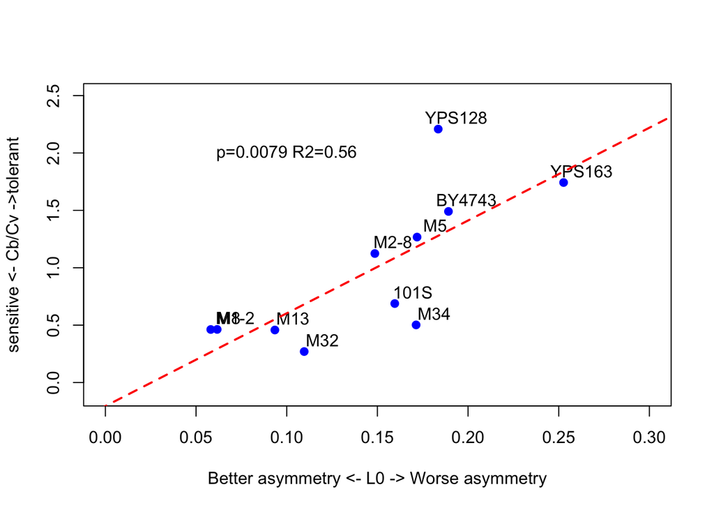

```r
 plot( tb3$Cb.vs.Cv ~ tb3$L0.all, col='blue', pch=19, xlab='Better asymmetry <- L0 -> Worse asymmetry', ylab='sensitive <- Cb/Cv ->tolerant', xlim=c(0, 0.3),ylim=c(-0.1,2.5) )
 text(tb3$L0.all + 0.01, tb3$Cb.vs.Cv+0.1, tb3$strain)
 m = lm(tb3$Cb.vs.Cv ~ tb3$L0.all )
 abline(m, col='red', lty=2, lwd=2)
 text(0.1, 2.0, "p=0.0079 R2=0.56")
```

Try 1/L0. However, this may cause confusion when readers try to compare this study with Qin08PONE finding.

```r
 #summary(lm(1/ tb3$Cb.vs.Cv ~ tb3$L0.small)) # p =0.685
 summary(lm( tb3$Cb.vs.Cv ~  tb3$L0.all)) # p=0.0079
```

```
##
## Call:
## lm(formula = tb3$Cb.vs.Cv ~ tb3$L0.all)
##
## Residuals:
##      Min       1Q   Median       3Q      Max
## -0.67801 -0.24589  0.08283  0.16792  0.92957
##
## Coefficients:
##             Estimate Std. Error t value Pr(>|t|)
## (Intercept)  -0.2050     0.3711  -0.552  0.59406
## tb3$L0.all    8.0835     2.3787   3.398  0.00789 **
## ---
## Signif. codes:  0 '***' 0.001 '**' 0.01 '*' 0.05 '.' 0.1 ' ' 1
##
## Residual standard error: 0.4455 on 9 degrees of freedom
##   (1 observation deleted due to missingness)
## Multiple R-squared:  0.562,  Adjusted R-squared:  0.5133
## F-statistic: 11.55 on 1 and 9 DF,  p-value: 0.007895
```

```r
 tb3$One.vs.L0.all = 1 / tb3$L0.all  #use 1/L0 maybe confusing. especially when peope try to compare Qin08 with this work.
 summary(lm( tb3$Cb.vs.Cv ~  tb3$One.vs.L0.all)) # p=0.039
```

```
##
## Call:
## lm(formula = tb3$Cb.vs.Cv ~ tb3$One.vs.L0.all)
##
## Residuals:
##      Min       1Q   Median       3Q      Max
## -0.69769 -0.39168  0.06582  0.25724  0.97397
##
## Coefficients:
##                   Estimate Std. Error t value Pr(>|t|)
## (Intercept)        1.71798    0.34764   4.942   0.0008 ***
## tb3$One.vs.L0.all -0.08880    0.03678  -2.414   0.0390 *
## ---
## Signif. codes:  0 '***' 0.001 '**' 0.01 '*' 0.05 '.' 0.1 ' ' 1
##
## Residual standard error: 0.5244 on 9 degrees of freedom
##   (1 observation deleted due to missingness)
## Multiple R-squared:  0.3931, Adjusted R-squared:  0.3257
## F-statistic: 5.829 on 1 and 9 DF,  p-value: 0.03896
```

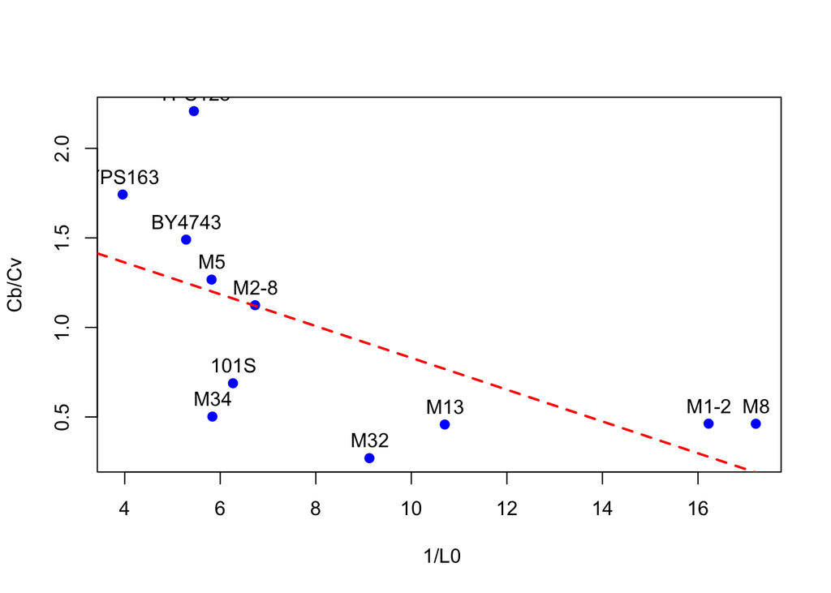

```r
 plot( tb3$Cb.vs.Cv ~ tb3$One.vs.L0.all, col='blue', pch=19, xlab=' 1/L0', ylab='Cb/Cv' )
 text(tb3$One.vs.L0.all + 0.01, tb3$Cb.vs.Cv+0.1, tb3$strain)
 m = lm(tb3$Cb.vs.Cv ~ tb3$One.vs.L0.all )
 abline(m, col='red', lty=2, lwd=2)
```

Regression analysis

```r
 pTb = 1: length(tb3[1,])
 names(pTb) = names(tb3)
 for( j in c(2:41) ) {
   #m = lm( tb3a[, j] ~ tb3a$ARLS, na.rm=T)
   m = lm( tb3[, j] ~ tb3$Cb.vs.Cv )
   #m = lm( tb3a[, j] ~ tb3a$CvMean, na.rm=T)
   #m = lm( tb3a[, j] ~ tb3a$CbMean, na.rm=T)
   sm = summary(m)
   pTb[j] = 1 - pf(sm$fsta[1], sm$fsta[2], sm$fsta[3])
 }
 pTb[pTb<0.05]
```

```
        ARLS       L0.all    CLS.vs.Tc     bminH2O2     bmaxH2O2
0.0392109400 0.0078946548 0.0354310798 0.0139759187 0.0047376191
    Cv.vs.Cb Cv.vs.Cb.STD     Cb.vs.Cv
0.0001815387 0.0362846069 0.0000000000
```

Cb0.5.vs.Cv ~ minimal full-black frequence in CLS. What does this mean? This correlation seems to hinge on YPS128. Decide not to use this correlation in the H2O2-LOH manuscript.

```r
 summary(lm( tb3$Cb0.5.vs.Cv ~  tb3$b.min)) # p=0.036 ,R2=0.40
```

```
##
## Call:
## lm(formula = tb3$Cb0.5.vs.Cv ~ tb3$b.min)
##
## Residuals:
##      Min       1Q   Median       3Q      Max
## -1.67203 -0.71691 -0.02567  0.29138  1.94160
##
## Coefficients:
##             Estimate Std. Error t value Pr(>|t|)
## (Intercept)   0.7500     0.4141   1.811    0.104
## tb3$b.min   186.5609    75.7792   2.462    0.036 *
## ---
## Signif. codes:  0 '***' 0.001 '**' 0.01 '*' 0.05 '.' 0.1 ' ' 1
##
## Residual standard error: 1.155 on 9 degrees of freedom
##   (1 observation deleted due to missingness)
## Multiple R-squared:  0.4024, Adjusted R-squared:  0.336
## F-statistic: 6.061 on 1 and 9 DF,  p-value: 0.03605
```

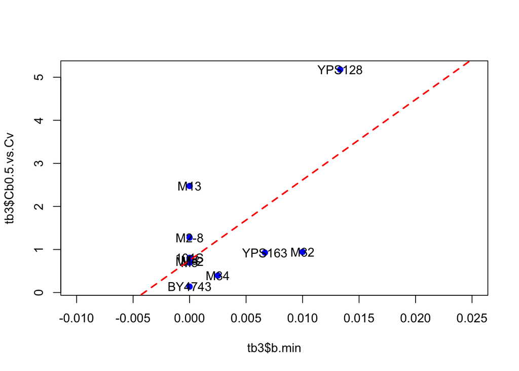

```r
 plot( tb3$Cb0.5.vs.Cv ~ tb3$b.min, col='blue', pch=19, xlim=c(-0.01, 0.025) )
 text(tb3$b.min, tb3$Cb0.5.vs.Cv, tb3$strain)
 m = lm(tb3$Cb0.5.vs.Cv  ~ tb3$b.min )
 abline(m, col='red', lty=2, lwd=2)
 text(0.1, 2.0, "p=0.036 R2=0.40")
```

```r
 pTb = 1: length(tb3[1,])
 names(pTb) = names(tb3)
 for( j in c(2:41) ) {
   #m = lm( tb3a[, j] ~ tb3a$ARLS, na.rm=T)
   m = lm( tb3[, j] ~ tb3$Cb0.5.vs.Cv)
   #m = lm( tb3a[, j] ~ tb3a$CvMean, na.rm=T)
   #m = lm( tb3a[, j] ~ tb3a$CbMean, na.rm=T)
   sm = summary(m)
   pTb[j] = 1 - pf(sm$fsta[1], sm$fsta[2], sm$fsta[3])
 }
 pTb[pTb<0.1]
```

```
##           TLmax           b.min        bminH2O2        bmaxH2O2
##    6.321115e-02    3.604597e-02    2.648181e-04    1.371843e-03
##     Cb0.5.vs.Cv Cb0.5.vs.Cv.STD        Cb.05STD
##    0.000000e+00    1.551670e-07    5.132811e-03
```

Data consistency check

```r
 summary(lm( tb3$CbMean ~  tb3$CvMean))
```

```
##
## Call:
## lm(formula = tb3$CbMean ~ tb3$CvMean)
##
## Residuals:
##       Min        1Q    Median        3Q       Max
## -0.025854 -0.010667 -0.001107  0.008249  0.036469
##
## Coefficients:
##             Estimate Std. Error t value Pr(>|t|)
## (Intercept) 0.006306   0.009432   0.669  0.51894
## tb3$CvMean  0.856764   0.149481   5.732  0.00019 ***
## ---
## Signif. codes:  0 '***' 0.001 '**' 0.01 '*' 0.05 '.' 0.1 ' ' 1
##
## Residual standard error: 0.01984 on 10 degrees of freedom
## Multiple R-squared:  0.7666, Adjusted R-squared:  0.7433
## F-statistic: 32.85 on 1 and 10 DF,  p-value: 0.0001899
```

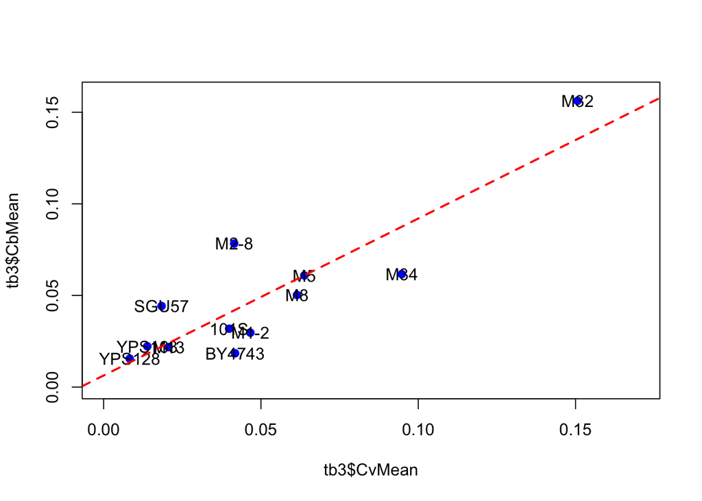

```r
 plot( tb3$CbMean ~ tb3$CvMean, col='blue', pch=19, xlim=c(0, 0.17), ylim=c(0,0.16) )
 text(tb3$CvMean, tb3$CbMean, tb3$strain)
 m = lm(tb3$CbMean  ~ tb3$CvMean )
 abline(m, col='red', lty=2, lwd=2)
```

```r
 summary(lm( tb3$Cb0.5Mean ~  tb3$CvMean))
```

```
##
## Call:
## lm(formula = tb3$Cb0.5Mean ~ tb3$CvMean)
##
## Residuals:
##       Min        1Q    Median        3Q       Max
## -0.034389 -0.009966 -0.007170  0.019582  0.034381
##
## Coefficients:
##             Estimate Std. Error t value Pr(>|t|)
## (Intercept)  0.01424    0.01115   1.277  0.23034
## tb3$CvMean   0.59123    0.17670   3.346  0.00742 **
## ---
## Signif. codes:  0 '***' 0.001 '**' 0.01 '*' 0.05 '.' 0.1 ' ' 1
##
## Residual standard error: 0.02345 on 10 degrees of freedom
## Multiple R-squared:  0.5282, Adjusted R-squared:  0.481
## F-statistic:  11.2 on 1 and 10 DF,  p-value: 0.007415
```

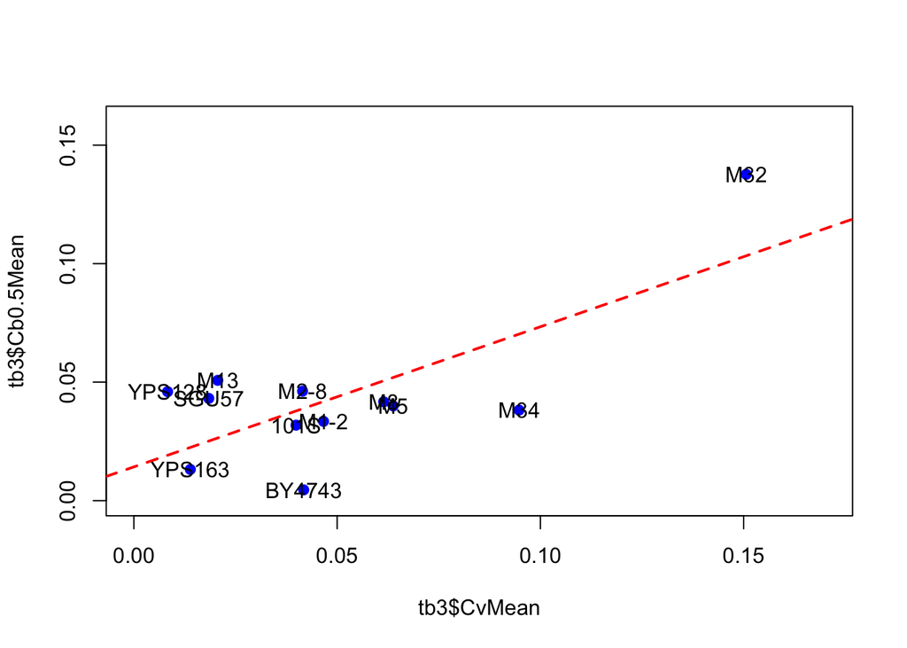

```r
 plot( tb3$Cb0.5Mean ~ tb3$CvMean, col='blue', pch=19, xlim=c(0, 0.17), ylim=c(0,0.16) )
 text(tb3$CvMean, tb3$Cb0.5Mean, tb3$strain)
 m = lm(tb3$Cb0.5Mean  ~ tb3$CvMean )
 abline(m, col='red', lty=2, lwd=2)
```

```r
 summary(lm( tb3$Cb0.5Mean ~  tb3$CbMean))
```

```
##
## Call:
## lm(formula = tb3$Cb0.5Mean ~ tb3$CbMean)
##
## Residuals:
##       Min        1Q    Median        3Q       Max
## -0.018698 -0.012903 -0.001178  0.006908  0.026684
##
## Coefficients:
##             Estimate Std. Error t value Pr(>|t|)
## (Intercept) 0.008288   0.008048   1.030 0.327323
## tb3$CbMean  0.722598   0.130004   5.558 0.000241 ***
## ---
## Signif. codes:  0 '***' 0.001 '**' 0.01 '*' 0.05 '.' 0.1 ' ' 1
##
## Residual standard error: 0.01688 on 10 degrees of freedom
## Multiple R-squared:  0.7555, Adjusted R-squared:  0.731
## F-statistic: 30.89 on 1 and 10 DF,  p-value: 0.0002413
```

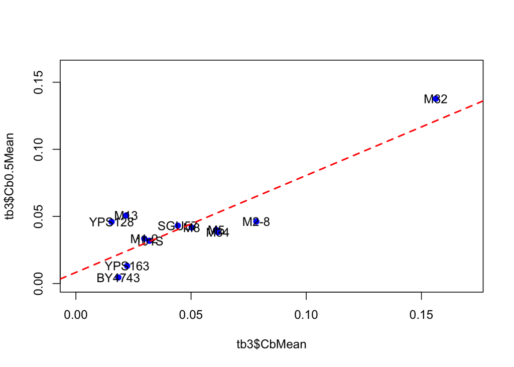

```r
 plot( tb3$Cb0.5Mean ~ tb3$CbMean, col='blue', pch=19, xlim=c(0, 0.17), ylim=c(0,0.16) )
 text(tb3$CbMean, tb3$Cb0.5Mean, tb3$strain)
 m = lm(tb3$Cb0.5Mean  ~ tb3$CbMean )
 abline(m, col='red', lty=2, lwd=2)
```

```r
 pTb2 = 1: length(tb3[1,])
 names(pTb2) = names(tb3)
 for( j in c(2:38) ) {
   m = lm( tb3[, j] ~ ( tb3$Cb0.5Mean))
   #m = lm( tb3a[, j] ~ tb3a$CvMean, na.rm=T)
   #m = lm( tb3a[, j] ~ tb3a$CbMean, na.rm=T)
   sm = summary(m)
   pTb2[j] = 1 - pf(sm$fsta[1], sm$fsta[2], sm$fsta[3])
 }
 pTb2[pTb2<0.05]
```

```
##       CvManu    CvManuSTD       CvMean        CvSTD       CbMean
## 0.0050616007 0.0005836548 0.0074151552 0.0007418509 0.0002412994
##        CbSTD     Cv.vs.Cb Cv.vs.Cb.STD    Cb0.5Mean
## 0.0035395976 0.0057037439 0.0002793327 0.0000000000
```

```r
 pTb2 = 1: length(tb3[1,])
 names(pTb2) = names(tb3)
 for( j in c(2:38) ) {
   m = lm( tb3[, j] ~ ( tb3$CbManu))
   #m = lm( tb3a[, j] ~ tb3a$CvMean, na.rm=T)
   #m = lm( tb3a[, j] ~ tb3a$CbMean, na.rm=T)
   sm = summary(m)
   pTb2[j] = 1 - pf(sm$fsta[1], sm$fsta[2], sm$fsta[3])
 }
 pTb2[pTb2<0.075]
```

```
##   L0.small  CLS.vs.Tc   Tg.vs.Tc     CvManu     CvMean      CvSTD
## 0.01231221 0.06537462 0.05274154 0.06441624 0.03964427 0.06795442
##     CbManu     CbMean
## 0.00000000 0.03873183
```

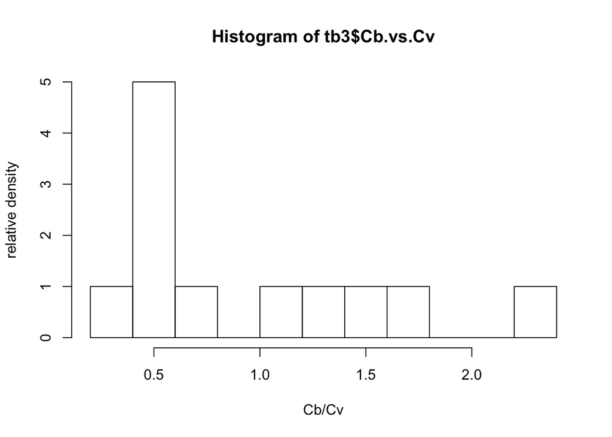

```r
 ### side by side bar-plots of Tg/Tc Cb/Cv
 mystep=0.2
 my.breaks = seq( 0.2,  round(max( c( tb3$Cb.vs.Cv, tb3$Tg.vs.Tc )) + 0.2, 1) ,by= mystep );
# my.breaks3 = seq( 0.1,  round(max( c( tb3$Cb.vs.Cv, tb$Tg.vs.Tc ) + 0.1, 1)) ,by= mystep );
 h.H2O2  <- hist( tb3$Cb.vs.Cv, br= my.breaks, xlab = "Cb/Cv", ylab = "relative density", freq = TRUE ) ;
```

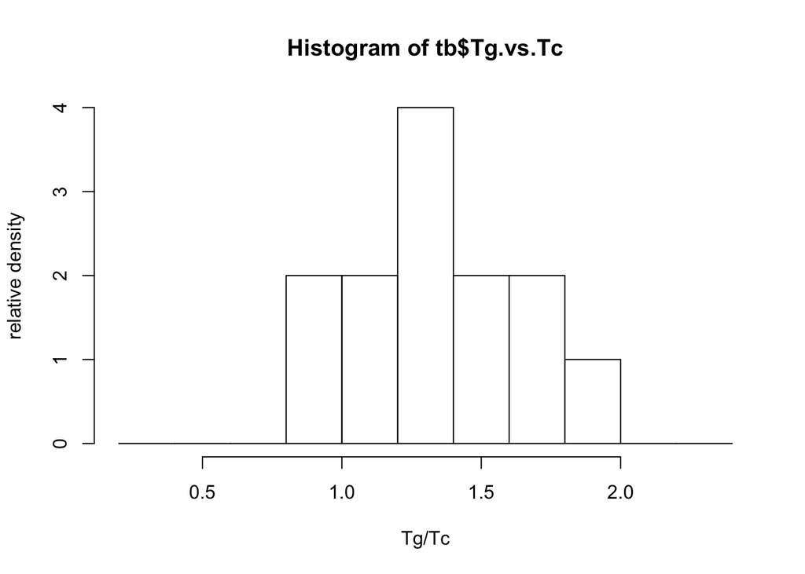

```r
# h.H2O2  <- hist( tb3$Cb.vs.Cv, br= 10, xlab = "Cb/Cv", ylab = "relative density", freq=F ) ;

 h.aging <- hist(tb$Tg.vs.Tc, br= my.breaks, xlab = "Tg/Tc",  ylab = "relative density", freq = TRUE ) ;
```

```r
 #generate the comparison table
# bins <-  data.frame( rbind(h.H2O2$density,h.aging$density) )  ; 20160721
 bins <-  data.frame( rbind(h.H2O2$counts,h.aging$counts) )  ; #20160721

  my.mids = my.breaks[-length(my.breaks)] + mystep/2
 #my.mids
 names( bins ) <- my.mids
 row.names(bins) <- c( "H2O2", "Chronological Aging" )
# row.names(bins3) <- c( "H2O2", "Chronological Aging", "H2O2 Mean" )
 bins
```

```
##                     0.3 0.5 0.7 0.9 1.1 1.3 1.5 1.7 1.9 2.1 2.3
## H2O2                  1   5   1   0   1   1   1   1   0   0   1
## Chronological Aging   0   0   0   2   2   4   2   2   1   0   0
```

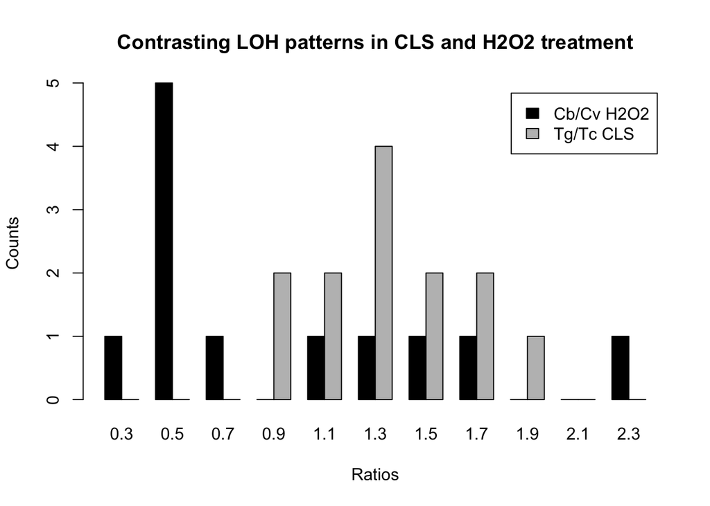

```r
# bins3

 #pdf("plots/Figure_sideBYside20131209.pdf", width=8, height=5)
# tiff("plots/Figure_sideBYside20131209.tif", width=480, height=480)
 barplot( as.matrix(bins), beside=T, col=c("black","gray"), ylab="Counts", xlab="Ratios",
          legend= c( "Cb/Cv H2O2", "Tg/Tc CLS" )  );
 title(main="Contrasting LOH patterns in CLS and H2O2 treatment" )
```

```r
# dev.off();

# Does probablity density x bin_width sum to 1?
sum(h.H2O2$density)* 0.2
```

```
## [1] 1
```

```r
sum(h.aging$density)*0.2
```

```
## [1] 1
```

```r
 ks.test(tb3$Cb.vs.Cv, tb3$Tg.vs.Tc) #p=0.031
```

```
##
##  Two-sample Kolmogorov-Smirnov test
##
## data:  tb3$Cb.vs.Cv and tb3$Tg.vs.Tc
## D = 0.58333, p-value = 0.03144
## alternative hypothesis: two-sided
```

```r
# tiff("plots/ARLS-CbCv-20131209.tif",width=480,height=480)
 par(font=2)
 plot( tb3$ARLS ~ tb3$Cb.vs.Cv , pch=19, col="red", main="H2O2-LOH ~ ARLS, 20131209", ylim=c(22,38), xlim=c(0.1, 2.5)
       , ylab='ARLS',xlab='Cb/Cv Tolerance to H2O2-induced genomic instability')
 text( tb3$Cb.vs.Cv+0.08, tb3$ARLS+0.5, tb3$strain)
 m = lm(tb3$ARLS ~ tb3$Cb.vs.Cv  )
 abline( m, col="blue")
 summary(m)
```

```
##
## Call:
## lm(formula = tb3$ARLS ~ tb3$Cb.vs.Cv)
##
## Residuals:
##     Min      1Q  Median      3Q     Max
## -6.3870 -1.6373  0.0113  1.0047  6.7836
##
## Coefficients:
##              Estimate Std. Error t value Pr(>|t|)
## (Intercept)    26.317      2.005  13.129 1.25e-07 ***
## tb3$Cb.vs.Cv    4.307      1.816   2.371   0.0392 *
## ---
## Signif. codes:  0 '***' 0.001 '**' 0.01 '*' 0.05 '.' 0.1 ' ' 1
##
## Residual standard error: 3.791 on 10 degrees of freedom
## Multiple R-squared:  0.3599, Adjusted R-squared:  0.2958
## F-statistic: 5.622 on 1 and 10 DF,  p-value: 0.03921
```

```r
 text(1.75, 28,  "R2=0.36 p=0.039")
```

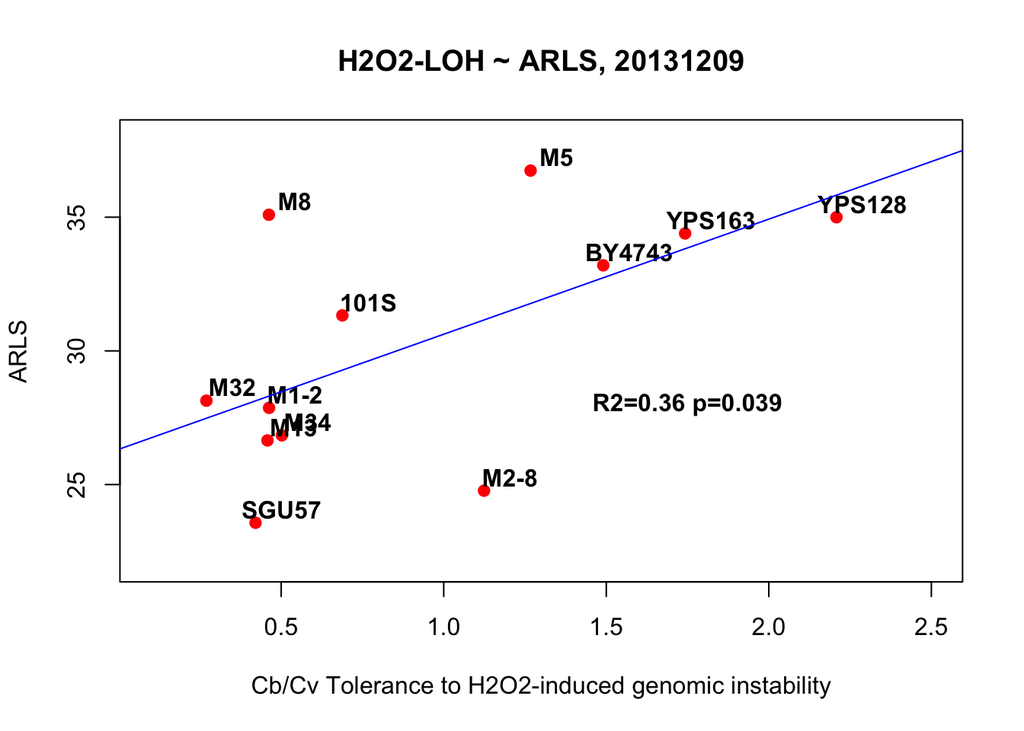

```r
# dev.off()


# tiff("plots/L0-CbCv-20131209.tif",width=480,height=480)
 par(font=2)
 plot( tb3$L0.all ~ tb3$Cb.vs.Cv , pch=19, col="red", main="H2O2-LOH ~ mitotic asymmetry, 20131209"
       ,xlim=c(0.1,2.5),ylim=c(0.28, 0.05)
       , ylab='L0.all mitotic asymmetry',xlab='Cb/Cv Tolerance to H2O2-induced genomic instability')
 text( tb3$Cb.vs.Cv+0.09, tb3$L0.all+0.008,tb3$strain)
 m = lm( tb3$L0.all ~ tb3$Cb.vs.Cv  )
 abline( m, col="blue")
 summary(m)
```

```
##
## Call:
## lm(formula = tb3$L0.all ~ tb3$Cb.vs.Cv)
##
## Residuals:
##       Min        1Q    Median        3Q       Max
## -0.051976 -0.032127  0.005828  0.023344  0.058495
##
## Coefficients:
##              Estimate Std. Error t value Pr(>|t|)
## (Intercept)   0.07795    0.02344   3.325  0.00886 **
## tb3$Cb.vs.Cv  0.06953    0.02046   3.398  0.00789 **
## ---
## Signif. codes:  0 '***' 0.001 '**' 0.01 '*' 0.05 '.' 0.1 ' ' 1
##
## Residual standard error: 0.04132 on 9 degrees of freedom
##   (1 observation deleted due to missingness)
## Multiple R-squared:  0.562,  Adjusted R-squared:  0.5133
## F-statistic: 11.55 on 1 and 9 DF,  p-value: 0.007895
```

```r
 text(0.8, 0.25, "R2=0.56 p=0.008")
```

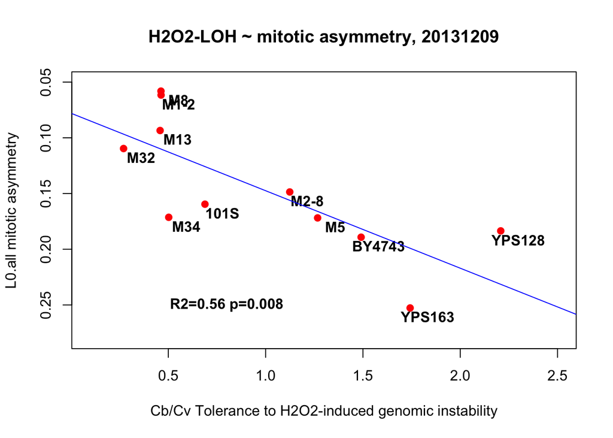

```r
# dev.off()


 ### Cv/Cb or Cb/Cv ~ robustness? I need a positive proxy
 #summary(lm( tb3$Cv.vs.Cb ~ tb3$G ) )  #positive, p=0.20,
 #summary(lm( tb3$Cb.vs.Cv ~ tb3$G ) )  #negative, p=0.25
```

(Tg/Tc)/(Cb/Cv)

```r
tb3$TgTc.vs.CbCv =  tb3$Tg.vs.Tc / tb3$Cb.vs.Cv
tb3$CbCv.vs.TgTc =  tb3$Cb.vs.Cv / tb3$Tg.vs.Tc

  pTb = 1: length(tb3[1,])
 names(pTb) = names(tb3)
 for( j in c(2:41) ) {
   #m = lm( tb3a[, j] ~ tb3a$ARLS, na.rm=T)
   m = lm( tb3[, j] ~ tb3$TgTc.vs.CbCv)
   #m = lm( tb3a[, j] ~ tb3a$CvMean, na.rm=T)
   #m = lm( tb3a[, j] ~ tb3a$CbMean, na.rm=T)
   sm = summary(m)
   pTb[j] = 1 - pf(sm$fsta[1], sm$fsta[2], sm$fsta[3])
 }
 pTb[pTb<0.1]
```

```
##         ARLS          CLS         Lmax        b.min       L0.all
## 0.0904361036 0.0812578725 0.0655552226 0.0867072678 0.0041828931
##    CLS.vs.Tc     Cv.vs.Cb Cv.vs.Cb.STD     Cb.vs.Cv
## 0.0039918637 0.0002414272 0.0439414529 0.0005940402
```

```r
  pTb = 1: length(tb3[1,])
 names(pTb) = names(tb3)
 for( j in c(2:41) ) {
   #m = lm( tb3a[, j] ~ tb3a$ARLS, na.rm=T)
   m = lm( tb3[, j] ~ tb3$CbCv.vs.TgTc)
   #m = lm( tb3a[, j] ~ tb3a$CvMean, na.rm=T)
   #m = lm( tb3a[, j] ~ tb3a$CbMean, na.rm=T)
   sm = summary(m)
   pTb[j] = 1 - pf(sm$fsta[1], sm$fsta[2], sm$fsta[3])
 }
 pTb[pTb<0.1]
```

```
##         ARLS           Tc        Tmmax           Td        Tdmax
## 8.450445e-02 8.204619e-02 7.412840e-02 6.488352e-02 8.557902e-02
##       L0.all    CLS.vs.Tc     bminH2O2     bmaxH2O2     Cv.vs.Cb
## 1.533460e-02 2.074282e-02 5.416255e-02 8.423929e-02 4.536773e-04
## Cv.vs.Cb.STD     Cb.vs.Cv
## 4.296594e-02 1.963929e-05
```

Plot TgTc.vs.CbCv CbCv.vs.TgTc ~L0 for publication

```r
summary(lm(tb3$L0.all ~  tb3$CbCv.vs.TgTc ))
```

```
##
## Call:
## lm(formula = tb3$L0.all ~ tb3$CbCv.vs.TgTc)
##
## Residuals:
##      Min       1Q   Median       3Q      Max
## -0.05399 -0.02589 -0.01484  0.02165  0.07974
##
## Coefficients:
##                  Estimate Std. Error t value Pr(>|t|)
## (Intercept)       0.08039    0.02555   3.146   0.0118 *
## tb3$CbCv.vs.TgTc  0.08414    0.02819   2.985   0.0153 *
## ---
## Signif. codes:  0 '***' 0.001 '**' 0.01 '*' 0.05 '.' 0.1 ' ' 1
##
## Residual standard error: 0.04426 on 9 degrees of freedom
##   (1 observation deleted due to missingness)
## Multiple R-squared:  0.4974, Adjusted R-squared:  0.4416
## F-statistic: 8.908 on 1 and 9 DF,  p-value: 0.01533
```

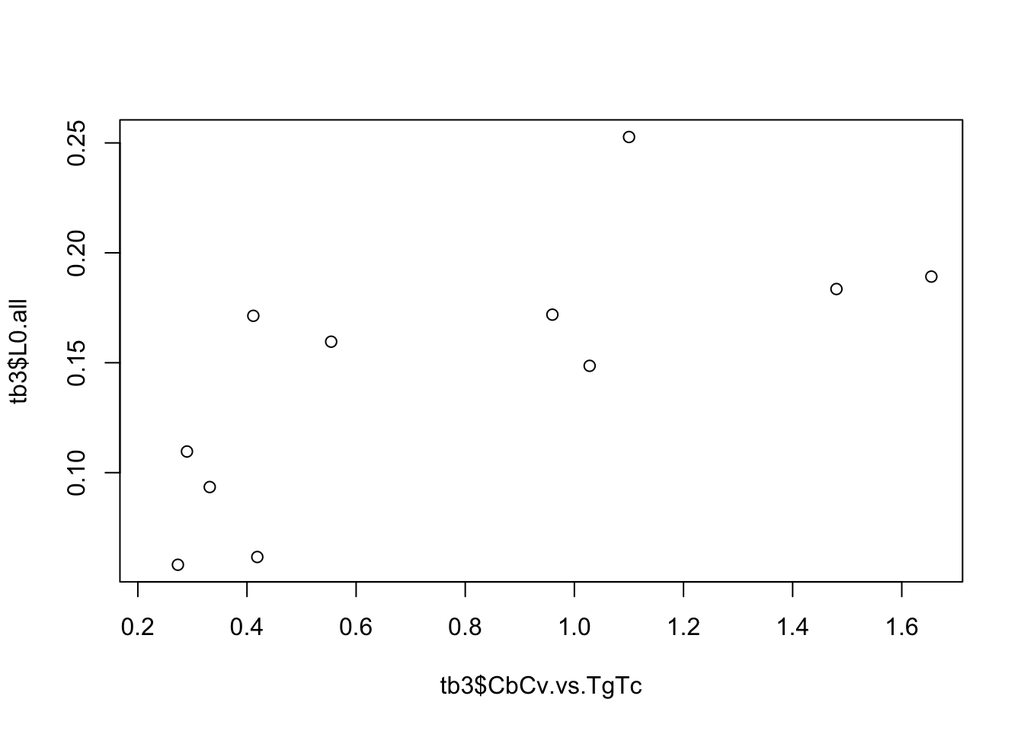

```r
plot( tb3$L0.all ~ tb3$CbCv.vs.TgTc)
```

```r
summary(lm(tb3$L0.all ~  tb3$TgTc.vs.CbCv ))
```

```
##
## Call:
## lm(formula = tb3$L0.all ~ tb3$TgTc.vs.CbCv)
##
## Residuals:
##       Min        1Q    Median        3Q       Max
## -0.064076 -0.013900 -0.008701  0.018626  0.066687
##
## Coefficients:
##                  Estimate Std. Error t value Pr(>|t|)
## (Intercept)       0.22307    0.02350   9.493 5.51e-06 ***
## tb3$TgTc.vs.CbCv -0.04078    0.01072  -3.805  0.00418 **
## ---
## Signif. codes:  0 '***' 0.001 '**' 0.01 '*' 0.05 '.' 0.1 ' ' 1
##
## Residual standard error: 0.03865 on 9 degrees of freedom
##   (1 observation deleted due to missingness)
## Multiple R-squared:  0.6167, Adjusted R-squared:  0.5741
## F-statistic: 14.48 on 1 and 9 DF,  p-value: 0.004183
```

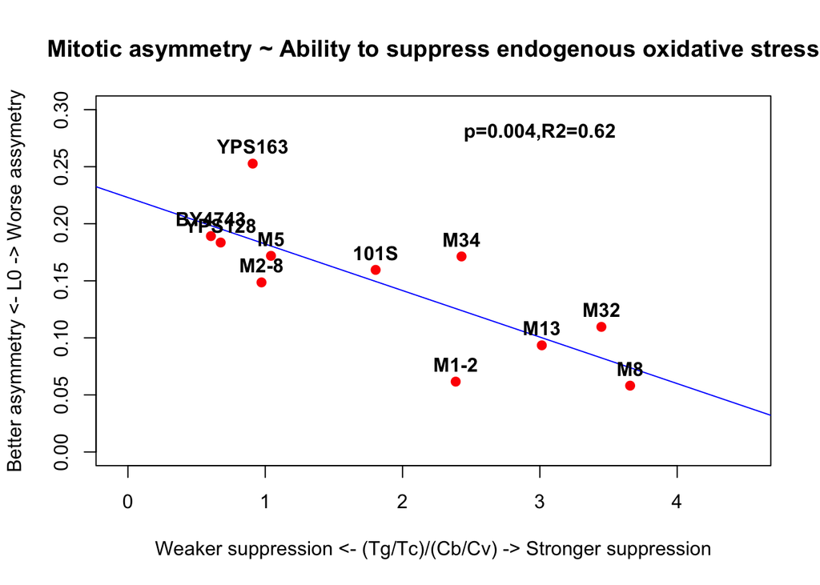

```r
m = lm(tb3$L0.all ~  tb3$TgTc.vs.CbCv)
par(font=2)
plot( tb3$L0.all ~ tb3$TgTc.vs.CbCv, pch=19, col="red",
      ylab = "Better asymmetry <- L0 -> Worse assymetry",
      xlab = "Weaker suppression <- (Tg/Tc)/(Cb/Cv) -> Stronger suppression",
      main="Mitotic asymmetry ~ Ability to suppress endogenous oxidative stress",
      xlim = c(-0.05, 4.5), ylim=c(0, 0.3))
abline(m, col="blue")
text( tb3$TgTc.vs.CbCv, tb3$L0.all+0.015, tb3$strain)
text( 3, 0.28, "p=0.004,R2=0.62")
```

For comparison to lm(tb3$L0.all ~ tb3$TgTc.vs.CbCv, other similar regressions

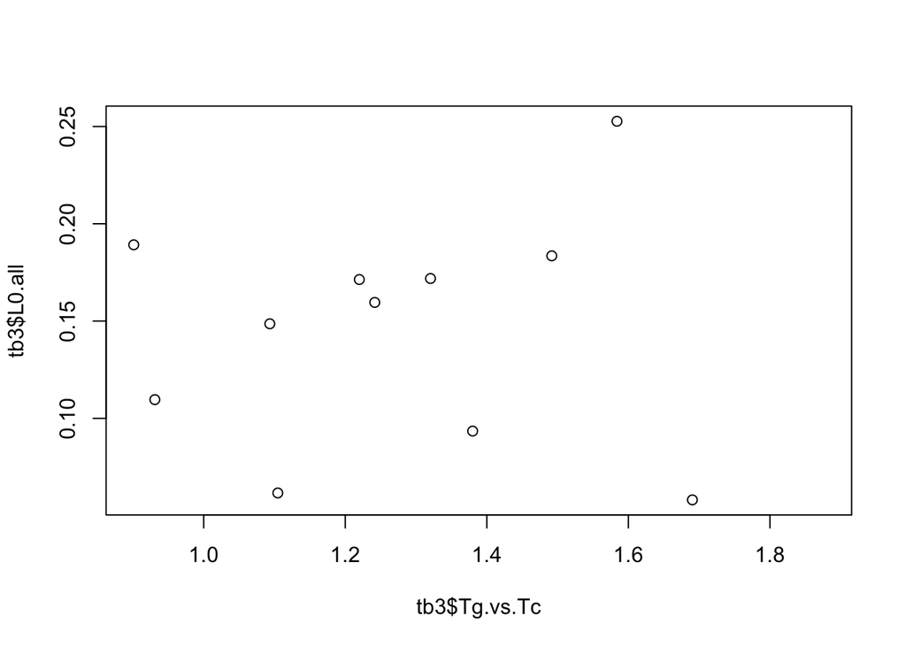

```r
plot( tb3$L0.all ~ tb3$Tg.vs.Tc)
```

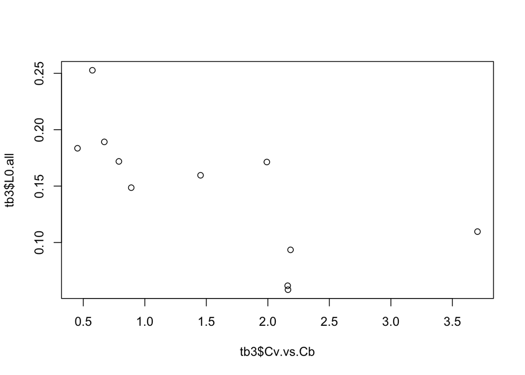

```r
plot( tb3$L0.all ~ tb3$Cv.vs.Cb)
```

```r
summary(lm(tb3$L0.all ~  tb3$Cv.vs.Cb ))
```

```
##
## Call:
## lm(formula = tb3$L0.all ~ tb3$Cv.vs.Cb)
##
## Residuals:
##       Min        1Q    Median        3Q       Max
## -0.061826 -0.024873 -0.005018  0.027245  0.066873
##
## Coefficients:
##              Estimate Std. Error t value Pr(>|t|)
## (Intercept)   0.20960    0.02578   8.130 1.94e-05 ***
## tb3$Cv.vs.Cb -0.04144    0.01419  -2.921    0.017 *
## ---
## Signif. codes:  0 '***' 0.001 '**' 0.01 '*' 0.05 '.' 0.1 ' ' 1
##
## Residual standard error: 0.04473 on 9 degrees of freedom
##   (1 observation deleted due to missingness)
## Multiple R-squared:  0.4867, Adjusted R-squared:  0.4296
## F-statistic: 8.533 on 1 and 9 DF,  p-value: 0.017
```